# Logistic Regression

yoda

2017년 9월 3일

### 1. 로지스틱 회귀분석

일반 회귀분석과 동일하게 종속변수와 독립변수 간의 관계를 나타내어

향후 예측 모델을 생성하는데 있다.

일반 회귀분석과의 차이점은 종속변수에 연속형 대신 범주형 데이터를 대상으로 하며

입력데이터가 주어졌을 경우, 특정 분류로 나눠지기 때문에 분류분석 방법으로 분류된다.

여기서는 판매여부 변수인 SOLD를 종속변수로 하여 데이터 중 70%를 훈련데이터로, 30%를

테스트데이터로 나누어서 분석을 실행한다.

### 2. 데이터 로딩 및 확인

```r
data1 <- read.csv("perfact2.csv")
str(data1)
```

```
## 'data.frame':    38912 obs. of  15 variables:
##  $ ID        : int  16186605 16186608 16186617 16186621 16186632 16186644 16186673 16186674 16186678 16186679 ...
##  $ POSTDATE  : Factor w/ 276 levels "2016-11-30","2016-12-01",..: 1 1 1 1 1 1 1 1 1 1 ...
##  $ MODEL     : Factor w/ 13 levels "A1303","A1332",..: 10 13 12 8 11 9 4 10 8 8 ...
##  $ GB        : Factor w/ 6 levels "128GB","16GB",..: 2 1 4 2 5 5 4 5 5 5 ...
##  $ KRNAME    : Factor w/ 13 levels "아이폰 3GS","아이폰 4",..: 9 12 11 7 13 10 4 9 7 7 ...
##  $ POSTPRICE : int  390000 1030000 780000 230000 370000 510000 75000 420000 270000 300000 ...
##  $ CONTRACT  : Factor w/ 3 levels "모름","요금할인약정 가능",..: 1 1 1 1 1 1 1 1 1 1 ...
##  $ GUARANTEE : Factor w/ 3 levels "무상 보증기간 남음 ",..: 1 1 1 3 1 2 2 3 2 2 ...
##  $ CHANGES   : Factor w/ 2 levels "유심기변","확정기변": 2 1 1 1 2 2 2 2 2 2 ...
##  $ CONDITIONS: Factor w/ 4 levels "미사용","상(새제품 수준/무흠집)",..: 2 1 1 2 2 2 3 3 2 3 ...
##  $ COMPONENT : Factor w/ 3 levels "구성품 일부 누락",..: 1 1 1 1 1 1 1 1 3 1 ...
##  $ SOLD      : Factor w/ 2 levels "no","yes": 2 1 1 2 1 1 1 2 2 1 ...
##  $ RELDATE   : Factor w/ 10 levels "2009-11-28","2010-09-10",..: 7 9 9 6 8 7 4 7 6 6 ...
##  $ RELPRICE  : int  869000 1152800 869000 789800 699600 1130800 946000 999900 924000 924000 ...
##  $ FALLRATE  : num  55.1 10.7 10.2 70.9 47.1 54.9 92.1 58 70.8 67.5 ...
```

(총 38912개 관측치, 15개 변수)

### 3. 변수타입 변환 및 연속형변수 표준화

```r
# 연속형 변수의 타입 변환
data1$POSTDATE <- as.numeric(as.Date(data1$POSTDATE))
data1$RELPRICE   <- as.numeric(data1$RELPRICE)
data1$FALLRATE <- as.numeric(data1$FALLRATE)
data1$RELDATE <- as.numeric(as.Date(data1$RELDATE))
data1$POSTPRICE <- as.numeric(data1$POSTPRICE)

# 연속형 변수의 표준화
data1$RELPRICE   <- scale(data1$RELPRICE)
data1$FALLRATE <- scale(data1$FALLRATE)
data1$POSTDATE <- scale(data1$POSTDATE)
data1$RELDATE <- scale(data1$RELDATE)
data1$POSTPRICE <- scale(data1$POSTPRICE)
```

종속변수 판매여부(SOLD)를 설명하는 변수인 POSTPRICE, POSTDATE, FALLRATE, RELPRICE, RELDATE의

단위가 다르기 때문에 표준화를 해야한다.

표준화방법에는 scale()을 통한 z변환, min값과 max값을 이용하는 [0~1]변환이 있으며 여기서는

z변환을 사용한다.

### 3. 훈련데이터와 테스트데이터 나누기

```r
library(caret)
library(Hmisc)
# SOLD 변수의 yes/no 빈도수 확인
describe(data1$SOLD)
```

```
## data1$SOLD
##        n  missing distinct
##    38912        0        2
##
## Value         no   yes
## Frequency  25266 13646
## Proportion 0.649 0.351
```

```r
# 훈련데이터 7 : 테스트데이터 3
part<-createDataPartition(data1$SOLD,p=0.7)
ind.train<-part$Resample1
data2.train<-data1[ind.train,]
data2.test<-data1[-ind.train,]
```

### 4. 훈련데이터 7 : 테스트데이터 3 비율로 나눈 후 확인

```r
describe(data2.train$SOLD)
```

```
## data2.train$SOLD
##        n  missing distinct
##    27240        0        2
##
## Value         no   yes
## Frequency  17687  9553
## Proportion 0.649 0.351
```

```r
describe(data2.test$SOLD)
```

```
## data2.test$SOLD
##        n  missing distinct
##    11672        0        2
##
## Value         no   yes
## Frequency   7579  4093
## Proportion 0.649 0.351
```

### 5. 훈련데이터로 로지스틱 회귀분석 실행

```r
names(data1)
```

```
##  [1] "ID"         "POSTDATE"   "MODEL"      "GB"         "KRNAME"
##  [6] "POSTPRICE"  "CONTRACT"   "GUARANTEE"  "CHANGES"    "CONDITIONS"
## [11] "COMPONENT"  "SOLD"       "RELDATE"    "RELPRICE"   "FALLRATE"
```

```r
train_logit <- glm(SOLD~KRNAME+GB+CONTRACT+GUARANTEE+CHANGES
                   +CONDITIONS+COMPONENT+POSTDATE, family=binomial, data=data2.train)

# 다중공선성이 높은 변수를 순차적으로 제거
library(car)
vif(train_logit)
```

```
##                 GVIF Df GVIF^(1/(2*Df))
## KRNAME     12.573097 12        1.111246
## GB          9.045833  5        1.246364
## CONTRACT    1.685790  2        1.139465
## GUARANTEE   2.823405  2        1.296264
## CHANGES     1.659198  1        1.288099
## CONDITIONS  1.809278  3        1.103869
## COMPONENT   1.588024  2        1.122572
## POSTDATE    1.421034  1        1.192071
```

```r
# 오즈비 확인
exp(coef(train_logit))
```

```
##                       (Intercept)                    KRNAME아이폰 4
##                         0.7647294                         0.8962161
##                   KRNAME아이폰 4S                    KRNAME아이폰 5
##                         1.9623186                         1.4846420
##                   KRNAME아이폰 5C                   KRNAME아이폰 5S
##                         2.6001640                         1.2321046
##                    KRNAME아이폰 6             KRNAME아이폰 6 플러스
##                         1.0571607                         1.0022853
##                   KRNAME아이폰 6S            KRNAME아이폰 6S 플러스
##                         0.8076015                         0.7123017
##                    KRNAME아이폰 7             KRNAME아이폰 7 플러스
##                         0.5144644                         0.4297658
##                   KRNAME아이폰 SE                            GB16GB
##                         1.2654939                         1.2663801
##                           GB256GB                            GB32GB
##                         0.7614852                         1.3167020
##                            GB64GB                             GB8GB
##                         1.3681273                         0.8053702
##         CONTRACT요금할인약정 가능         CONTRACT요금할인약정 불가
##                         0.9966599                         1.1988423
##      GUARANTEE무상 보증기간 만료                   GUARANTEE미확인
##                         1.0943007                         0.9765289
##                   CHANGES확정기변  CONDITIONS상(새제품 수준/무흠집)
##                         0.9860427                         0.8148666
##   CONDITIONS중 (생활흠집 외 양호)      CONDITIONS하(번인/잔상/파손)
##                         0.6651236                         0.6784641
##   COMPONENT단품 (기기본체만 있음) COMPONENT박스 및 모든 구성품 포함
##                         0.6388038                         0.8863433
##                          POSTDATE
##                         1.0326193
```

### 6. 훈련데이터로 나온 결과를 토대로 테스트데이터 로지스틱회귀분석 실행

```r
test.pred <- predict(train_logit, newdata=data2.test, type="response")
```

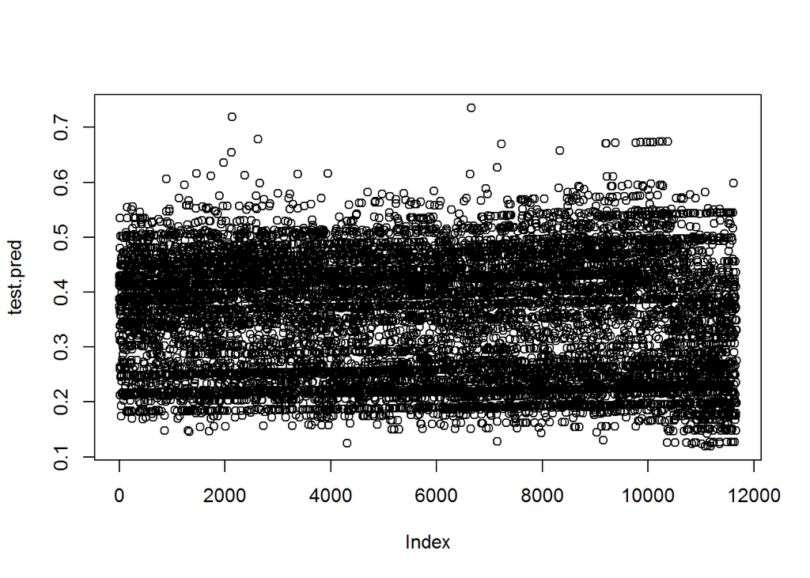

```r
plot(test.pred)
```

### 7. 훈련데이터의 로지스틱회귀분석의 최적모델을 찾기 위해 stepwise 실행

```r
train_logit.step <- step(train_logit, direction="both")
```

```
## Start:  AIC=33913.11
## SOLD ~ KRNAME + GB + CONTRACT + GUARANTEE + CHANGES + CONDITIONS +
##     COMPONENT + POSTDATE
##
##              Df Deviance   AIC
## - CHANGES     1    33855 33911
## <none>             33855 33913
## - POSTDATE    1    33859 33915
## - GUARANTEE   2    33862 33916
## - CONTRACT    2    33874 33928
## - GB          5    33903 33951
## - COMPONENT   2    33902 33956
## - CONDITIONS  3    33929 33981
## - KRNAME     12    34158 34192
##
## Step:  AIC=33911.22
## SOLD ~ KRNAME + GB + CONTRACT + GUARANTEE + CONDITIONS + COMPONENT +
##     POSTDATE
##
##              Df Deviance   AIC
## <none>             33855 33911
## + CHANGES     1    33855 33913
## - POSTDATE    1    33860 33914
## - GUARANTEE   2    33862 33914
## - CONTRACT    2    33878 33930
## - GB          5    33903 33949
## - COMPONENT   2    33902 33954
## - CONDITIONS  3    33933 33983
## - KRNAME     12    34158 34190
```

변수를 하나씩 제거하면서 최적 모델을 찾음.

AIC는 모형의 설명력을 나타내는 척도로 값이 작을수록 유의한 모형이다.

종속변수(SOLD) 판매여부에 유의한 변수는 다음과 같다.

```r
formula(train_logit.step)
```

```
## SOLD ~ KRNAME + GB + CONTRACT + GUARANTEE + CONDITIONS + COMPONENT +
##     POSTDATE
```

### 8. 훈련데이터의 STEPWISE를 통해 구한 최적모델을 통해 다시 훈련용데이터 로지스틱회귀분석 실행

```r
train_logit.best <- glm(formula(train_logit.step), family=binomial, data=data2.train)
summary(train_logit.best)
```

```
##
## Call:
## glm(formula = formula(train_logit.step), family = binomial, data = data2.train)
##
## Deviance Residuals:
##     Min       1Q   Median       3Q      Max
## -1.5347  -0.9788  -0.7189   1.2572   2.0629
##
## Coefficients:
##                                    Estimate Std. Error z value Pr(>|z|)
## (Intercept)                       -0.275733   0.389908  -0.707 0.479458
## KRNAME아이폰 4                    -0.109676   0.450440  -0.243 0.807628
## KRNAME아이폰 4S                    0.675211   0.484613   1.393 0.163529
## KRNAME아이폰 5                     0.395795   0.396944   0.997 0.318714
## KRNAME아이폰 5C                    0.954654   0.535882   1.781 0.074837
## KRNAME아이폰 5S                    0.209401   0.387901   0.540 0.589313
## KRNAME아이폰 6                     0.056576   0.385351   0.147 0.883278
## KRNAME아이폰 6 플러스              0.003023   0.387886   0.008 0.993782
## KRNAME아이폰 6S                   -0.213043   0.386370  -0.551 0.581363
## KRNAME아이폰 6S 플러스            -0.338437   0.387974  -0.872 0.383035
## KRNAME아이폰 7                    -0.663659   0.388024  -1.710 0.087200
## KRNAME아이폰 7 플러스             -0.843050   0.389161  -2.166 0.030286
## KRNAME아이폰 SE                    0.236555   0.389697   0.607 0.543835
## GB16GB                             0.235099   0.067563   3.480 0.000502
## GB256GB                           -0.274066   0.122853  -2.231 0.025691
## GB32GB                             0.275028   0.049325   5.576 2.46e-08
## GB64GB                             0.312310   0.067667   4.615 3.92e-06
## GB8GB                             -0.217447   0.708457  -0.307 0.758897
## CONTRACT요금할인약정 가능         -0.005936   0.033853  -0.175 0.860804
## CONTRACT요금할인약정 불가          0.185137   0.045846   4.038 5.39e-05
## GUARANTEE무상 보증기간 만료        0.089238   0.044870   1.989 0.046724
## GUARANTEE미확인                   -0.024445   0.056784  -0.430 0.666845
## CONDITIONS상(새제품 수준/무흠집)  -0.208089   0.039164  -5.313 1.08e-07
## CONDITIONS중 (생활흠집 외 양호)   -0.411335   0.047565  -8.648  < 2e-16
## CONDITIONS하(번인/잔상/파손)      -0.390998   0.099053  -3.947 7.90e-05
## COMPONENT단품 (기기본체만 있음)   -0.448475   0.074117  -6.051 1.44e-09
## COMPONENT박스 및 모든 구성품 포함 -0.120264   0.031436  -3.826 0.000130
## POSTDATE                           0.032331   0.015555   2.078 0.037666
##
## (Intercept)
```

[output cut: 22 more lines]

```
## CONDITIONS중 (생활흠집 외 양호)   ***
## CONDITIONS하(번인/잔상/파손)      ***
## COMPONENT단품 (기기본체만 있음)   ***
## COMPONENT박스 및 모든 구성품 포함 ***
## POSTDATE                          *
## ---
## Signif. codes:  0 '***' 0.001 '**' 0.01 '*' 0.05 '.' 0.1 ' ' 1
##
## (Dispersion parameter for binomial family taken to be 1)
##
##     Null deviance: 35296  on 27239  degrees of freedom
## Residual deviance: 33855  on 27212  degrees of freedom
## AIC: 33911
##
## Number of Fisher Scoring iterations: 4
```

### 9. 훈련용데이터를 통해 얻은 최적모델로 테스트데이터 로지스틱회귀분석 실행

```r
library(ROCR)
test.pred.best <- predict(train_logit.best, newdata=data2.test, type="response")
test.pred.best2 <- prediction(test.pred.best, data2.test$SOLD)
head(test.pred.best, 20)
```

```
##         1        10        11        15        22        25        26
## 0.3738867 0.4297780 0.3877990 0.4282458 0.4135937 0.4167061 0.3222896
##        30        33        36        39        45        46        55
## 0.2654501 0.3393801 0.2105595 0.4801328 0.5348049 0.3653135 0.4135937
##        59        64        65        68        72        76
## 0.3863191 0.3653135 0.2598923 0.4109672 0.3129591 0.5028077
```

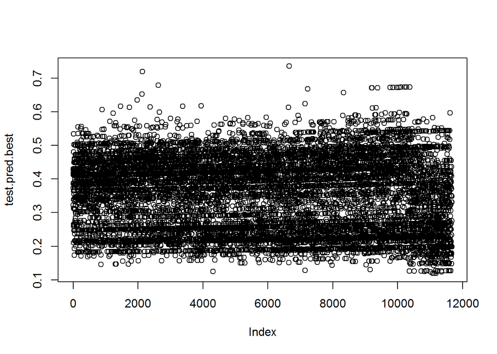

```r
plot(test.pred.best)
```

### 10. data2.test의 판매여부(SOLD)를 타겟으로 설정하고 예측 성능 확인

```r
test_target <- data2.test$SOLD
lr_trn_predicted <- rep(0, length(test_target))
lr_trn_predicted[which(test.pred.best >= 0.4)] <- 1

# 판매완료면 1, 아니면 0으로 설정
data2.test$SOLD2 <- ifelse(data2.test$SOLD=="yes", 1, 0)

# 성능확인
library(e1071)
confusionMatrix(lr_trn_predicted,data2.test$SOLD2)
```

```
## Confusion Matrix and Statistics
##
##           Reference
## Prediction    0    1
##          0 5065 1999
##          1 2514 2094
##
##                Accuracy : 0.6133
##                  95% CI : (0.6044, 0.6222)
##     No Information Rate : 0.6493
##     P-Value [Acc > NIR] : 1
##
##                   Kappa : 0.1748
##  Mcnemar's Test P-Value : 1.991e-14
##
##             Sensitivity : 0.6683
##             Specificity : 0.5116
##          Pos Pred Value : 0.7170
##          Neg Pred Value : 0.4544
##              Prevalence : 0.6493
##          Detection Rate : 0.4339
##    Detection Prevalence : 0.6052
##       Balanced Accuracy : 0.5899
##
##        'Positive' Class : 0
##
```

Accuracy는 전체 정확도를 뜻하며 약 61%의 정확도를 가지고 있다.

Sensitivity는 실제로 값이 0일 경우에 0이라고 예측할 확률

Specificity는 실제로 값이 1일 경우에 1이라고 에측할 확률

Pos Pred Value는 0으로 예측했는데 실제로 0일 확률

Neg Pred Value는 1로 예측했는데 실제로 1일 확률

0(SOLD no)는 예측을 잘 했으나 1(SOLD yes)에 대한 예측의 정확도가 떨어진다.

이는 SOLD 변수의 값들이 신뢰성이 떨어지거나 표본수 부족 또는 독립변수와의 관계를

원인으로 판단할 수 있다.

### 11. AUC 확인

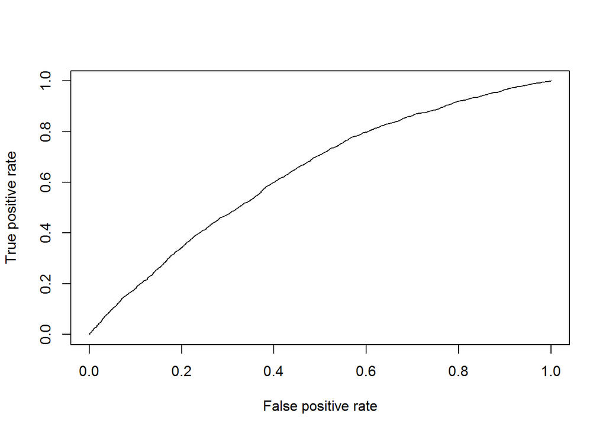

```r
df_pred2 <- prediction(test.pred.best, data2.test$SOLD2)
plot(performance(df_pred2, "tpr", "fpr"))
```

```r
performance(df_pred2, "auc")
```

```
## An object of class "performance"
## Slot "x.name":
## [1] "None"
##
## Slot "y.name":
## [1] "Area under the ROC curve"
##
## Slot "alpha.name":
## [1] "none"
##
## Slot "x.values":
## list()
##
## Slot "y.values":
## [[1]]
## [1] 0.6369495
##
##
## Slot "alpha.values":
## list()
```

```r
auc <- performance(test.pred.best2, measure="auc")
auc <- auc@y.values[1]
auc
```

```
## [[1]]
## [1] 0.6369495
```

약 63%의예측률로 예측이 제대로 되지 않음을 알 수 있다.

excellent = 0.9~1

good = 0.8~0.9

fair = 0.7~0.8

poor = 0.6~0.7

fail = 0.5~0.6

# 모델링 & 분석 - 차원축소

```r
anova(train_logit, test="Chisq")
```

```
## Analysis of Deviance Table
##
## Model: binomial, link: logit
##
## Response: SOLD
##
## Terms added sequentially (first to last)
##
##
##            Df Deviance Resid. Df Resid. Dev  Pr(>Chi)
## NULL                       27239      35296
## KRNAME     12  1238.43     27227      34058 < 2.2e-16 ***
## GB          5    45.12     27222      34013 1.370e-08 ***
## CONTRACT    2    35.37     27220      33977 2.082e-08 ***
## GUARANTEE   2     3.57     27218      33974   0.16739
## CHANGES     1     3.94     27217      33970   0.04727 *
## CONDITIONS  3    67.97     27214      33902 1.163e-14 ***
## COMPONENT   2    42.60     27212      33859 5.620e-10 ***
## POSTDATE    1     4.25     27211      33855   0.03933 *
## ---
## Signif. codes:  0 '***' 0.001 '**' 0.01 '*' 0.05 '.' 0.1 ' ' 1
```

```r
# 유의한 변수로 다시 로지스틱 분석 실행
train_logit2 <- glm(SOLD ~ KRNAME+GB+CONTRACT+CONDITIONS+COMPONENT, data=data2.train, family="binomial")

# anova로 전 모델과 비교
anova(train_logit2, train_logit, test="Chisq")
```

```
## Analysis of Deviance Table
##
## Model 1: SOLD ~ KRNAME + GB + CONTRACT + CONDITIONS + COMPONENT
## Model 2: SOLD ~ KRNAME + GB + CONTRACT + GUARANTEE + CHANGES + CONDITIONS +
##     COMPONENT + POSTDATE
##   Resid. Df Resid. Dev Df Deviance Pr(>Chi)
## 1     27215      33866
## 2     27211      33855  4     11.1  0.02547 *
## ---
## Signif. codes:  0 '***' 0.001 '**' 0.01 '*' 0.05 '.' 0.1 ' ' 1
```

# ROC 커브 확인

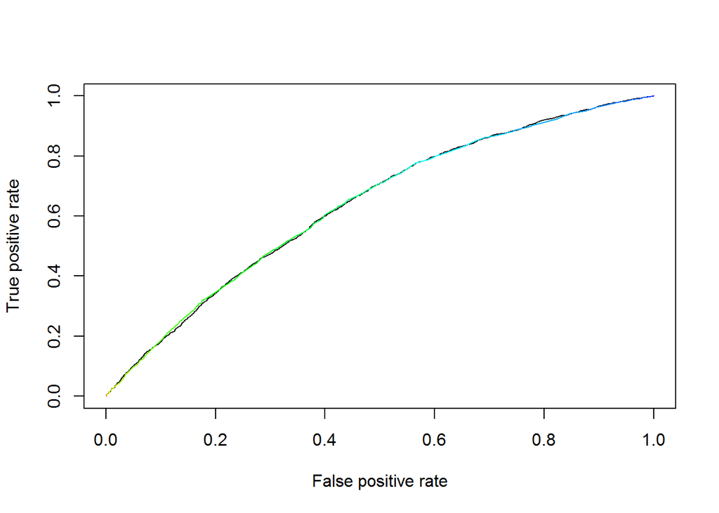

```r
test.pred2.best <- predict(train_logit2, newdata=data2.test, type="response")
test.pred2.best2 <- prediction(test.pred2.best, data2.test$SOLD)
test.pred.prf <- performance(test.pred.best2, measure = "tpr", x.measure = "fpr")
test.pred2.prf <- performance(test.pred2.best2, measure = "tpr", x.measure = "fpr")
plot(test.pred.prf)
plot(test.pred2.prf, add = TRUE, colorize = TRUE)
```

두 커브선이 겹쳐보이는 것으로 보아 비슷한 결과가 나온다.